# Reproducible Research: Peer Assessment 1

### Loading and preprocessing the data

```r
dat <- read.csv(file = "activity.csv", header = TRUE, sep = ",")
head(dat, 5)
```

```
##   steps       date interval
## 1    NA 2012-10-01        0
## 2    NA 2012-10-01        5
## 3    NA 2012-10-01       10
## 4    NA 2012-10-01       15
## 5    NA 2012-10-01       20
```

### What is mean total number of steps taken per day?

We know that the data captures every 5 min. Therefore, in a day, there are 24*12 time intervals. Also, data was collected from 2012/10/01 to 2012/11/30, thus there will be 61 days.

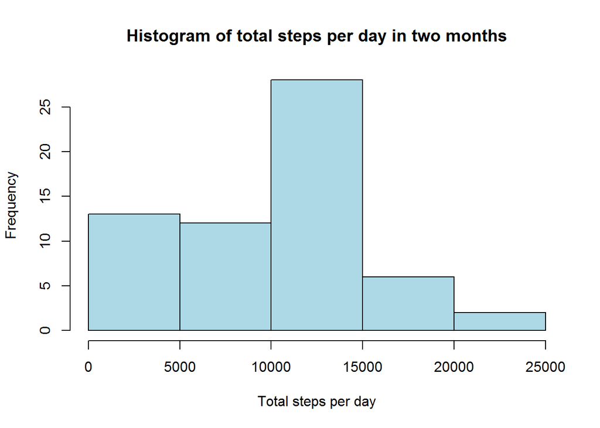

```r
#Create a new data
days <- seq(from=as.Date('2012-10-01'), to=as.Date("2012-11-30"),by='days' )

totalStep <- function(data){
  ndays = length(days)
  totStep <- numeric(ndays)
  for( i in seq_along(days)){
    sub = subset(data, as.Date(data$date) == days[i])
    totStep[i] <- sum(sub$steps, na.rm = TRUE)
  }
  return(totStep)
}

newdat <- data.frame(days = days, total.Steps = totalStep(dat))
#Plot the histogram
hist(newdat$total.Steps, col = "lightblue",
    main = "Histogram of total steps per day in two months",
    xlab = "Total steps per day")
```

```r
#Calculate meanStep and medianStep
mean(newdat$total.Steps)
```

```
## [1] 9354.23
```

```r
median(newdat$total.Steps)
```

```
## [1] 10395
```

### What is the average daily activity pattern?

Time-series of the 5 minutes interval (x-axis) and the average number of steps taken, averaged across all days (y-axis)

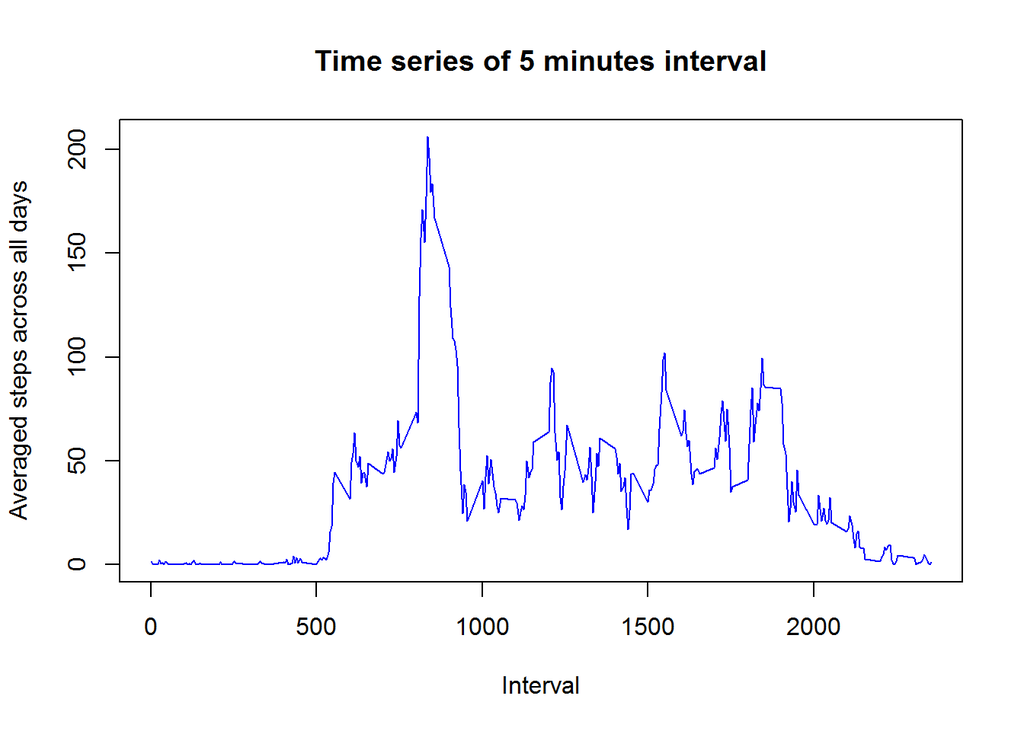

```r
#number of intervals per day
ninterval = 24*12
interval <- dat[1:ninterval,]$interval
#average number of steps taken per interval across all days

#Calculate mean Interval
meanInterval <- function(data){
  meanInterval <- numeric(ninterval)
  for( i in 1:length(interval)){
    sub = subset(data, data$interval == interval[i])
    meanInterval[i] = mean(sub$steps, na.rm = TRUE)
  }
  return(meanInterval)
}

#plot
plot(x = interval, y = meanInterval(dat), type = "l",
     main="Time series of 5 minutes interval",
     xlab = "Interval", ylab = "Averaged steps across all days",
     col = "blue")
```

```r
#Show the interval containing the maximum number of steps
interval[which.max(meanInterval(dat))]
```

```
## [1] 835
```

```r
#maximum number of steps at that interval
print(max(meanInterval(dat)))
```

```
## [1] 206.1698
```

The result shows that 8:35 is the peak time of the day with around 206 steps in average.

### Imputing missing values

There are many ways to impute the data. We could easily use some libraries, such as “Amelia” or “VIM” to perform automatic imputation. However, manual imputation is done herein as the problem requires to insert specific values into the missings.

```r
#total number of missing values
sum(is.na(x = dat))
```

```
## [1] 2304
```

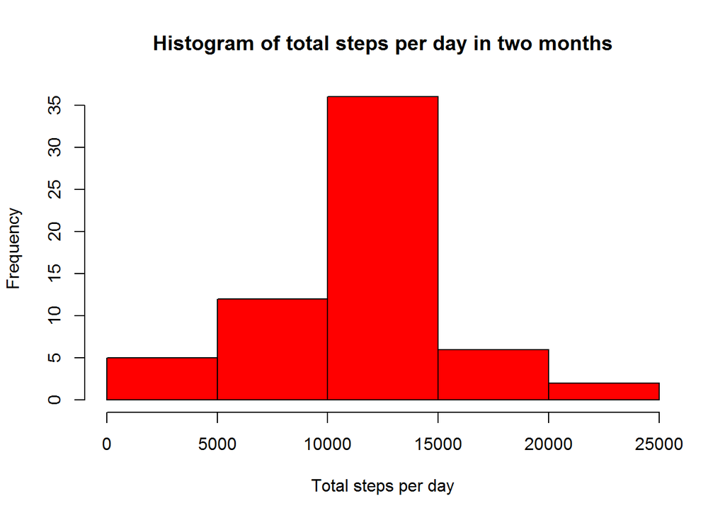

```r
#Fill in missing values
fillMissing <- function(data){
  temMean <- meanInterval(data)
  naIndex <- which(is.na(data) == TRUE)
  for (i in 1:length(naIndex)){
    for( j in 1:ninterval){
      if(data[naIndex[i],]$interval == interval[j]){
        data[naIndex[i],]$steps <- temMean[j]
      }
    }
  }
  return(data)
}

imputedat <- fillMissing(dat)
newdat <- data.frame(days = days, total.Steps = totalStep(imputedat))
#Plot the histogram
hist(newdat$total.Steps, col = "red",
    main = "Histogram of total steps per day in two months",
    xlab = "Total steps per day")
```

```r
#Calculate meanStep and medianStep
mean(newdat$total.Steps)
```

```
## [1] 10766.19
```

```r
median(newdat$total.Steps)
```

```
## [1] 10766.19
```

The histogram becomes slightly different. The most significance on the chart is still at around 10,000 to 15,000 steps. However, the proportion of 0-5000 steps decrease considerably.

Also, the mean and median of the new imputted data are equal, suggesting a better dataset.

### Are there differences in activity patterns between weekdays and weekends?

```r
library(lubridate)
```

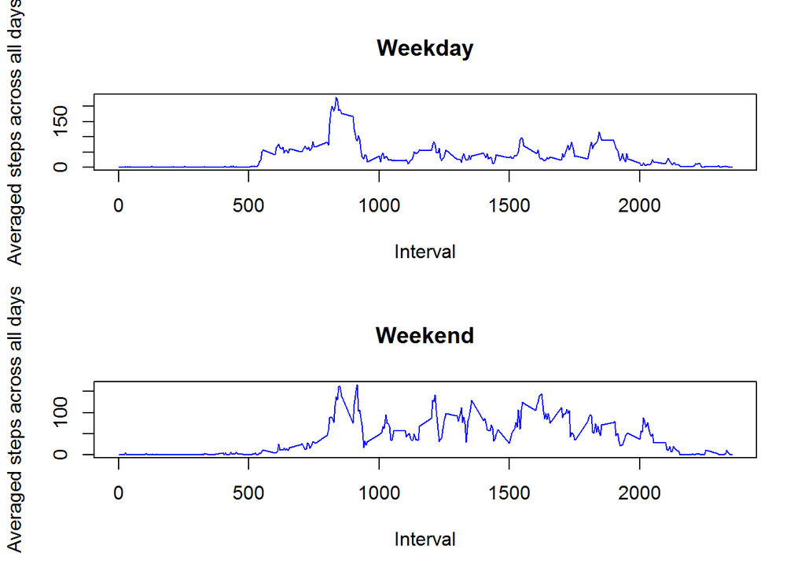

```r
convert <- function(date){

  if(wday(as.Date(date)) %in% 2:6){return ("weekday")}
  else {return ("weekend")}
}

imputedat$weektime <- do.call(rbind, lapply(imputedat$date, FUN = convert))

wdaydat <- subset(imputedat, imputedat$weektime == "weekday")
wkendat <- subset(imputedat, imputedat$weektime == "weekend")

par(mfrow = c( 2, 1 ))
#plot
plot(x = interval, y = meanInterval(wdaydat), type = "l",
     main="Weekday",
     xlab = "Interval", ylab = "Averaged steps across all days",
     col = "blue")
plot(x = interval, y = meanInterval(wkendat), type = "l",
     main="Weekend",
     xlab = "Interval", ylab = "Averaged steps across all days",
     col = "blue")
```

The figures show that step numbers taken during weekends fluctuate more wildly than those taken during weekdays.As can be seen, it is quite obvious that weekend activities are busier during the day than weekdays’.Having said that, both reach a peak at around 8:00 to 9:00, which witness the busiest time of the day.